# TASK 1 CODSOFT

## TASK - 1

## TITANIC SURVIVAL PREDICTION

## JAN BATCH A30

Introduction to the Titanic Dataset

The Titanic dataset encapsulates details of passengers aboard the ill-fated RMS Titanic. This historical dataset reveals insights into demographics, ticket class, and survival outcomes. Our goal is to leverage machine learning to predict survival probabilities based on these features, shedding light on the factors that influenced passengers' fate during this iconic maritime tragedy.

## Description about the columns(variables) in the dataset.

PassengerId: Unique identifier for each passenger.

Survived: Binary variable indicating whether a passenger survived or not (0 = Not Survived, 1 = Survived).

Pclass: Ticket class, representing the socio-economic status of the passenger (1 = 1st class, 2 = 2nd class, 3 = 3rd class).

Name: Name of the passenger.

Sex: Gender of the passenger (male or female).

Age: Age of the passenger.

SibSp: Number of siblings/spouses aboard the Titanic.

Parch: Number of parents/children aboard the Titanic.

Ticket: Ticket number.

Fare: Fare paid for the ticket.

Cabin: Cabin number where the passenger stayed.

Embarked: Port of embarkation (C = Cherbourg, Q = Queenstown, S = Southampton).

## Step 1: Import Libraries

```python
pip install pandas scikit-learn matplotlib
```

[output not shown]

[output not shown]

```python
import pandas as pd
from sklearn.model_selection import train_test_split
from sklearn.preprocessing import StandardScaler
from sklearn.ensemble import RandomForestClassifier
from sklearn.metrics import accuracy_score, confusion_matrix, classification_report
import matplotlib.pyplot as plt
import seaborn as sns
import numpy as np
```

## Step 2: Load and Explore the Dataset

```python
df = pd.read_csv("C:/Users/MANOJ S/Downloads/archive (17)/Titanic-Dataset.csv")
df
```

|  | PassengerId | Survived | Pclass | Name | Sex | Age | SibSp | Parch | Ticket | Fare | Cabin | Embarked |
| --- | --- | --- | --- | --- | --- | --- | --- | --- | --- | --- | --- | --- |
| 0 | 1 | 0 | 3 | Braund, Mr. Owen Harris | male | 22.0 | 1 | 0 | A/5 21171 | 7.2500 | NaN | S |
| 1 | 2 | 1 | 1 | Cumings, Mrs. John Bradley (Florence Briggs Th... | female | 38.0 | 1 | 0 | PC 17599 | 71.2833 | C85 | C |
| 2 | 3 | 1 | 3 | Heikkinen, Miss. Laina | female | 26.0 | 0 | 0 | STON/O2. 3101282 | 7.9250 | NaN | S |
| 3 | 4 | 1 | 1 | Futrelle, Mrs. Jacques Heath (Lily May Peel) | female | 35.0 | 1 | 0 | 113803 | 53.1000 | C123 | S |
| 4 | 5 | 0 | 3 | Allen, Mr. William Henry | male | 35.0 | 0 | 0 | 373450 | 8.0500 | NaN | S |
| ... | ... | ... | ... | ... | ... | ... | ... | ... | ... | ... | ... | ... |
| 886 | 887 | 0 | 2 | Montvila, Rev. Juozas | male | 27.0 | 0 | 0 | 211536 | 13.0000 | NaN | S |
| 887 | 888 | 1 | 1 | Graham, Miss. Margaret Edith | female | 19.0 | 0 | 0 | 112053 | 30.0000 | B42 | S |
| 888 | 889 | 0 | 3 | Johnston, Miss. Catherine Helen "Carrie" | female | NaN | 1 | 2 | W./C. 6607 | 23.4500 | NaN | S |
| 889 | 890 | 1 | 1 | Behr, Mr. Karl Howell | male | 26.0 | 0 | 0 | 111369 | 30.0000 | C148 | C |
| 890 | 891 | 0 | 3 | Dooley, Mr. Patrick | male | 32.0 | 0 | 0 | 370376 | 7.7500 | NaN | Q |

891 rows × 12 columns

```python
# Explore the dataset
print(df.head())
```

```
   PassengerId  Survived  Pclass  \
0            1         0       3
1            2         1       1
2            3         1       3
3            4         1       1
4            5         0       3

                                                Name     Sex   Age  SibSp  \
0                            Braund, Mr. Owen Harris    male  22.0      1
1  Cumings, Mrs. John Bradley (Florence Briggs Th...  female  38.0      1
2                             Heikkinen, Miss. Laina  female  26.0      0
3       Futrelle, Mrs. Jacques Heath (Lily May Peel)  female  35.0      1
4                           Allen, Mr. William Henry    male  35.0      0

   Parch            Ticket     Fare Cabin Embarked
0      0         A/5 21171   7.2500   NaN        S
1      0          PC 17599  71.2833   C85        C
2      0  STON/O2. 3101282   7.9250   NaN        S
3      0            113803  53.1000  C123        S
4      0            373450   8.0500   NaN        S
```

```python
print(df.info())
```

```
<class 'pandas.core.frame.DataFrame'>
RangeIndex: 891 entries, 0 to 890
Data columns (total 12 columns):
 #   Column       Non-Null Count  Dtype
---  ------       --------------  -----
 0   PassengerId  891 non-null    int64
 1   Survived     891 non-null    int64
 2   Pclass       891 non-null    int64
 3   Name         891 non-null    object
 4   Sex          891 non-null    object
 5   Age          714 non-null    float64
 6   SibSp        891 non-null    int64
 7   Parch        891 non-null    int64
 8   Ticket       891 non-null    object
 9   Fare         891 non-null    float64
 10  Cabin        204 non-null    object
 11  Embarked     889 non-null    object
dtypes: float64(2), int64(5), object(5)
memory usage: 83.7+ KB
None
```

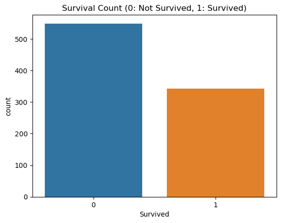

```python
# Visualize survival counts
sns.countplot(x='Survived', data=df)
plt.title('Survival Count (0: Not Survived, 1: Survived)')
plt.show()
```

[figure not shown]

```python
# Visualize survival based on gender
sns.countplot(x='Survived', hue='Sex', data=df)
plt.title('Survival Count based on Gender (0: Male, 1: Female)')
plt.show()
```

[output not shown]

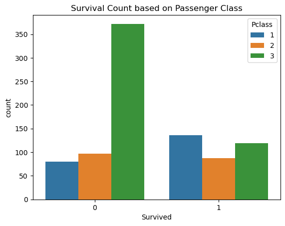

```python
# Visualize survival based on passenger class
sns.countplot(x='Survived', hue='Pclass', data=df)
plt.title('Survival Count based on Passenger Class')
plt.show()
```

## Step 3: Data Preprocessing

```python
# Fill missing Age values with median
df['Age'].fillna(df['Age'].median(), inplace=True)
```

```python
# Fill missing Embarked values with mode (if 'Embarked' column is present)
if 'Embarked' in df.columns:
    df['Embarked'].fillna(df['Embarked'].mode()[0], inplace=True)
```

```python
# Drop unnecessary columns if they exist
columns_to_drop = ['Cabin', 'Name', 'Ticket']
df.drop(columns_to_drop, axis=1, errors='ignore', inplace=True)
```

```python
# Convert categorical variables to numerical
df = pd.get_dummies(df, columns=['Sex', 'Pclass'], drop_first=True)
```

```python
# Separate features and target variable
X = df.drop('Survived', axis=1)
y = df['Survived']
```

```python
X
```

[output not shown]

```python
y
```

```
0      0
1      1
2      1
3      1
4      0
      ..
886    0
887    1
888    0
889    1
890    0
Name: Survived, Length: 891, dtype: int64
```

```python
# Split the data into training and testing sets
X_train, X_test, y_train, y_test = train_test_split(X, y, test_size=0.2, random_state=42)
```

```python
# Build and train the model (Random Forest Classifier)
model = RandomForestClassifier(random_state=42)
model.fit(X_train, y_train)
```

```
RandomForestClassifier(random_state=42)
```

```python
# Make predictions
y_pred = model.predict(X_test)
y_pred
```

```
array([0, 1, 0, 1, 0, 1, 1, 0, 1, 0, 1, 0, 0, 0, 1, 1, 1, 0, 0, 0, 0, 1,
       0, 0, 0, 0, 0, 1, 0, 0, 0, 0, 1, 0, 0, 0, 1, 0, 1, 0, 0, 0, 0, 0,
       0, 0, 0, 0, 0, 1, 1, 1, 0, 1, 0, 1, 1, 1, 0, 0, 0, 1, 1, 0, 0, 0,
       0, 1, 0, 1, 1, 1, 1, 1, 0, 1, 0, 1, 1, 0, 0, 1, 1, 1, 0, 0, 1, 1,
       0, 0, 0, 0, 1, 0, 0, 1, 1, 0, 1, 0, 0, 0, 1, 0, 0, 0, 0, 0, 0, 0,
       0, 0, 1, 0, 0, 0, 0, 1, 1, 0, 1, 1, 1, 1, 0, 0, 1, 1, 0, 0, 1, 0,
       0, 1, 1, 0, 1, 0, 0, 0, 0, 1, 1, 1, 0, 0, 0, 1, 0, 0, 0, 0, 0, 0,
       0, 0, 1, 1, 1, 0, 0, 0, 0, 1, 0, 0, 1, 0, 0, 0, 0, 1, 0, 1, 0, 0,
       0, 1, 1], dtype=int64)
```

```python
# Evaluate the model
accuracy = accuracy_score(y_test, y_pred)
conf_matrix = confusion_matrix(y_test, y_pred)
classification_rep = classification_report(y_test, y_pred)
```

```python
print(f"Accuracy: {accuracy}")
print(f"Confusion Matrix:\n{conf_matrix}")
print(f"Classification Report:\n{classification_rep}")
```

```
Accuracy: 0.7206703910614525
Confusion Matrix:
[[83 22]
 [28 46]]
Classification Report:
              precision    recall  f1-score   support

           0       0.75      0.79      0.77       105
           1       0.68      0.62      0.65        74

    accuracy                           0.72       179
   macro avg       0.71      0.71      0.71       179
weighted avg       0.72      0.72      0.72       179
```

The model achieved an accuracy of approximately 72.07%. This means that the model correctly predicted the survival or non-survival of passengers in about 72% of the cases.

## Confusion Matrix:

True Positives (TP): 46

True Negatives (TN): 83

False Positives (FP): 22

False Negatives (FN): 28

## Classification Report:

Precision: Precision for class 0 (not survived): 75%

Precision for class 1 (survived): 68%

Recall (Sensitivity or True Positive Rate):

Recall for class 0: 79%

Recall for class 1: 62%

F1-Score:

F1-Score for class 0: 77%

F1-Score for class 1: 65%

Interpretation: The precision indicates the percentage of correctly predicted instances among those predicted as either survived or not survived.

Recall reflects the percentage of correctly predicted instances among the actual instances of either survived or not survived.

The F1-Score is the harmonic mean of precision and recall, providing a balanced measure.

The model has a relatively good accuracy, but it's essential to consider precision and recall, especially in imbalanced datasets.

Further optimization or different model selection could be explored based on specific requirements or preferences for precision or recall.

## The model achieved an accuracy of approximately 72.07%, meaning it correctly predicted the survival or non-survival of passengers in about 72% of cases.

## The confusion matrix provides a detailed breakdown of predictions, showing that the model correctly identified 83 passengers who did not survive (True Negatives) and 46 passengers who did survive (True Positives). However, there were also 22 False Positives (predicted as survived but did not) and 28 False Negatives (predicted as not survived but did).

## The classification report further breaks down the performance metrics for each class (survived and not survived). Precision, recall, and F1-Score are provided for each class.

## In summary, the model has some predictive capability in distinguishing between passengers who survived and those who did not, but there is room for improvement, especially in reducing false positives and false negatives. Depending on the specific goals and requirements, further model optimization or exploration of different algorithms may be warranted.